# Practical Machine Learning Project

Alexandre VALETTE

7/19/2020

# Executive Summary

After loading and cleaning the data, two models have been fit to the training dataset. The Decision Trees model has an accuracy of 80%. The Random Forest model has an accuracy above 99%.

So, the Random Forest model has been used to predict the result with the Test Case dataset.

# Data processing

Loading the necessary libraries.

## Reading raw data

Raw data are download directly from an internet website, to the local machine. The data is then read into memory.

```r
training.url <- "https://d396qusza40orc.cloudfront.net/predmachlearn/pml-training.csv"
testing.url  <- "https://d396qusza40orc.cloudfront.net/predmachlearn/pml-testing.csv"
download.file(training.url, destfile="training.csv")
download.file(testing.url, destfile="testing.csv")
```

```r
training.data <- read.csv("training.csv", na.strings=c("NA",""))
testing.data <- read.csv("testing.csv", na.strings=c("NA",""))
```

## Cleaning data

Raw data presents some useless columns for prediction and some missing values, which are cleaned.

```r
# Drop columns with NA values
training.data <- training.data[,colSums(is.na(training.data)) == 0]
testing.data <- testing.data[,colSums(is.na(testing.data)) == 0]

# Remove useless columns for prediction
drops <- c("X","user_name","raw_timestamp_part_1","raw_timestamp_part_2","cvtd_timestamp","new_window")
training.data <- training.data[ , !(names(training.data) %in% drops)]
testing.data <- testing.data[ , !(names(testing.data) %in% drops)]

# Convert "Classe" to factor
training.data[, 54] <- factor(training.data[, 54])
testing.data[, 54] <- factor(testing.data[, 54])
```

## Cross validation

The training data is split in two, between the actual training dataset (60%), and a validation dataset (40%).

```r
in.training <- createDataPartition(training.data$classe, p=0.60, list=F)
validate.data <- training.data[-in.training, ]
training.data <- training.data[in.training, ]
```

# Data Exploration

Let’s first have a look at our data, with the help of a correlation matrix.

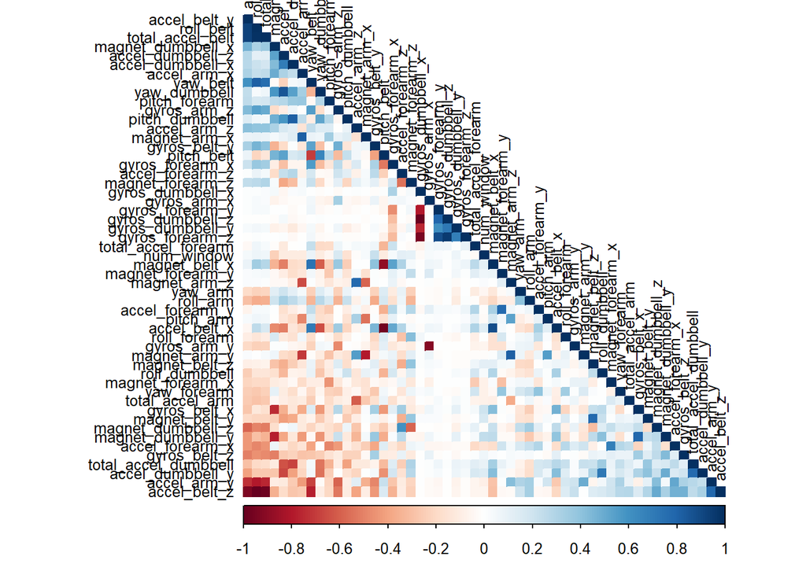

```r
corMatrix <- cor(training.data[, -54])
corrplot(corMatrix, order = "FPC", method = "color", type = "lower",
         tl.cex = 0.8, tl.col = rgb(0, 0, 0))
```

Some predictors are highly correlated which could lead to an higher variance for our prediction. Let’s keep in mind for the future that a possible improvement of our models is to first select less correlated predictors or to apply a PCA analysis.

# Data modelling

Two models are trained on the training dataset, then test on the validation dataset.

## Decision Trees

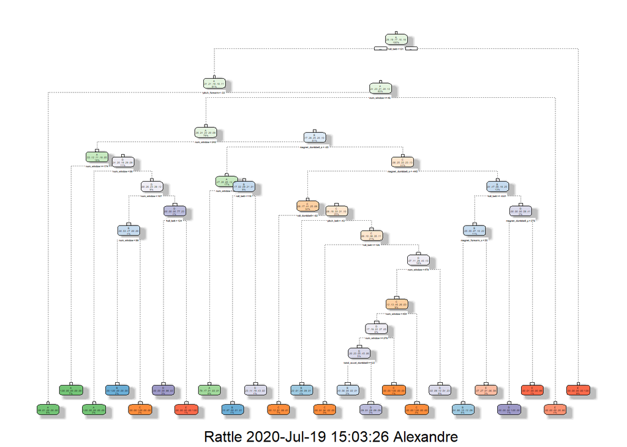

```r
set.seed(1)
fit_dt <- rpart(classe ~ ., data=training.data, method="class")
fancyRpartPlot(fit_dt)
```

```r
predictions_dt <- predict(fit_dt, validate.data, type = "class")
cm_dt <- confusionMatrix(predictions_dt, validate.data$classe)
cm_dt
```

```
## Confusion Matrix and Statistics
##
##           Reference
## Prediction    A    B    C    D    E
##          A 1881  115    0   21    4
##          B  204 1151   83  113   65
##          C    0   72 1106   38    5
##          D  121  104  177 1041  235
##          E   26   76    2   73 1133
##
## Overall Statistics
##
##                Accuracy : 0.8045
##                  95% CI : (0.7955, 0.8132)
##     No Information Rate : 0.2845
##     P-Value [Acc > NIR] : < 2.2e-16
##
##                   Kappa : 0.7538
##
##  Mcnemar's Test P-Value : NA
##
## Statistics by Class:
##
##                      Class: A Class: B Class: C Class: D Class: E
## Sensitivity            0.8427   0.7582   0.8085   0.8095   0.7857
## Specificity            0.9751   0.9265   0.9822   0.9029   0.9724
## Pos Pred Value         0.9307   0.7123   0.9058   0.6204   0.8649
## Neg Pred Value         0.9397   0.9411   0.9605   0.9603   0.9527
## Prevalence             0.2845   0.1935   0.1744   0.1639   0.1838
## Detection Rate         0.2397   0.1467   0.1410   0.1327   0.1444
## Detection Prevalence   0.2576   0.2060   0.1556   0.2139   0.1670
## Balanced Accuracy      0.9089   0.8424   0.8954   0.8562   0.8790
```

Accuracy of Decision Trees model is 80%.

## Random Forest

```r
set.seed(1)
fit_rf <- randomForest(classe ~ ., data=training.data)
prediction_rm <- predict(fit_rf, validate.data, type = "class")
cm_rf <- confusionMatrix(prediction_rm, validate.data$classe)
cm_rf
```

```
## Confusion Matrix and Statistics
##
##           Reference
## Prediction    A    B    C    D    E
##          A 2232    6    0    0    0
##          B    0 1511    4    0    0
##          C    0    1 1361   17    0
##          D    0    0    3 1268    0
##          E    0    0    0    1 1442
##
## Overall Statistics
##
##                Accuracy : 0.9959
##                  95% CI : (0.9942, 0.9972)
##     No Information Rate : 0.2845
##     P-Value [Acc > NIR] : < 2.2e-16
##
##                   Kappa : 0.9948
##
##  Mcnemar's Test P-Value : NA
##
## Statistics by Class:
##
##                      Class: A Class: B Class: C Class: D Class: E
## Sensitivity            1.0000   0.9954   0.9949   0.9860   1.0000
## Specificity            0.9989   0.9994   0.9972   0.9995   0.9998
## Pos Pred Value         0.9973   0.9974   0.9869   0.9976   0.9993
## Neg Pred Value         1.0000   0.9989   0.9989   0.9973   1.0000
## Prevalence             0.2845   0.1935   0.1744   0.1639   0.1838
## Detection Rate         0.2845   0.1926   0.1735   0.1616   0.1838
## Detection Prevalence   0.2852   0.1931   0.1758   0.1620   0.1839
## Balanced Accuracy      0.9995   0.9974   0.9961   0.9928   0.9999
```

Accuracy of Random Forest model is above 99% which is an huge improvement over Decision Trees model. This model is choosen for the prediction on the Test Case Dataset.

# Test Case

We apply the Random Forest model to the Test Case dataset.

```r
prediction_testcase <- predict(fit_rf, testing.data, type = "class")
prediction_testcase
```

```
##  1  2  3  4  5  6  7  8  9 10 11 12 13 14 15 16 17 18 19 20
##  B  A  B  A  A  E  D  B  A  A  B  C  B  A  E  E  A  B  B  B
## Levels: A B C D E
```